# Reddit x 100

Key Plots

Molly Lewis

2020-01-22

```r
AUTHOR_COUNTS <-  here("exploratory_analyses/03_systematic_sample/data/subreddit_counts_scores.csv")
author_count_measures <- read_csv(AUTHOR_COUNTS, col_names = c("subreddit","author_n","word_H","word_mean_n","word_sd","word_total","score_mean",                                                    "score_sd","score_H","comments_n_long","comments_n_all",
                                                               "posts_n_all","comments_posts_ratio")) %>%
  filter(author_n > 100) %>%
  arrange(-author_n) %>%
  mutate(author_rank = 1:n()) %>%
    filter(!(subreddit == "newsokur"))

author_counts <- author_count_measures %>%
  select(subreddit, author_n, author_rank)
```

Summary of findings:

- There’s a robust Zipf’s law relationship between number of words and community size - I don’t think this has ever been shown before!
- Larger communities produce more comments relative to posts (power law).
- Larger communities have members with longer lifespans
- Larger communities have shorter lags between comments on a thread (power law).
- Larger communities have less churn.
- Larger communities have more inequality across authors in terms of posting - relatively fewer people do more of the posting.
- Larger communities have lower (normalized) scores. This is a Zipf-like distribution.
- Larger communities have lower comment entropy (though weak).
- Larger communities have authors that are less coherent with respect to themselves, i.e. change more.

```r
#Implications for language change:
#* Larger communnities: more homogenous input because of inequality across speakers
# More consensus -> faster word gain.
```

## Language counts

More people, more words. (there’s no relationship between mean/sd post length and author n.)

### Total words

```r
r2 <- lm(unlist(log(author_count_measures[,"author_n"])) ~ unlist(log10(author_count_measures[,"word_total"]))) %>%
    summary() %>%
   pluck("r.squared") %>%
  round(2)
```

Quantity of language as a function of community size follows a power law, with an exponent of 1.04, meaning it’s a Zipfs law (~1). And an $R^2$ = 0.92!

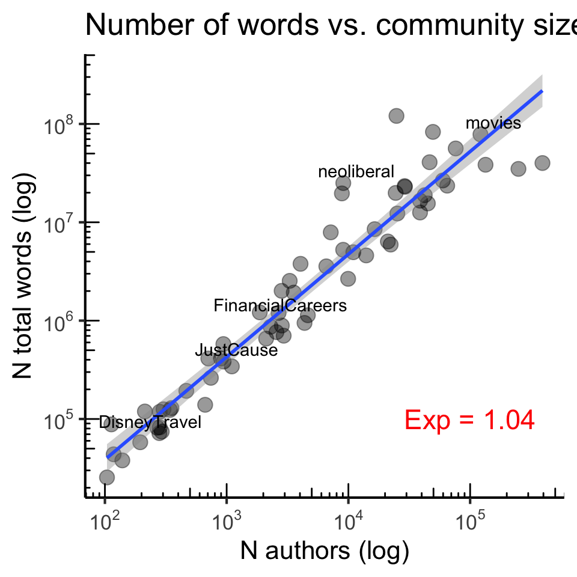

```r
exp_value <- get_power_law_exponent(author_count_measures, "author_n","word_total")[[1]]


label_data <- author_count_measures %>%
  filter(subreddit %in% c("DisneyTravel", "movies", "neoliberal", "JustCause", "FinancialCareers"))

ggplot(author_count_measures, aes(x = author_n, y = word_total)) +
  geom_point(size = 4, alpha = .4) +
  geom_smooth(method = "lm")+
  ggtitle("Number of words vs. community size") +
  geom_text_repel(data = label_data, aes(label = subreddit)) +
  scale_y_log10(name = "N total words (log)",
                labels = scales::trans_format("log10", scales::math_format(10^.x))) +
  scale_x_log10(name = "N authors (log)",
                labels = scales::trans_format("log10", scales::math_format(10^.x)))+
  annotation_logticks() +
  annotate("text", label = paste0("Exp = ", exp_value ),
           x = 100000, y = 100000, color= "red", size = 6) +
  theme_classic(base_size = 16)
```

### Author longevity

```r
AUTHOR_TIME <- here("exploratory_analyses/03_systematic_sample/data/subreddit_author_time_data.csv")
author_time <- read_csv(AUTHOR_TIME, col_names = c("subreddit", "author_longevity_mean", "author_sd_mean",
                                                   "author_longevity_H", "author_lag_sd", "author_lag_H", "author_lag_mean")) %>%
    left_join(author_counts) %>%
     filter(author_n > 100)
```

Time from first to last post - bigger communities have people with longer lifespans.

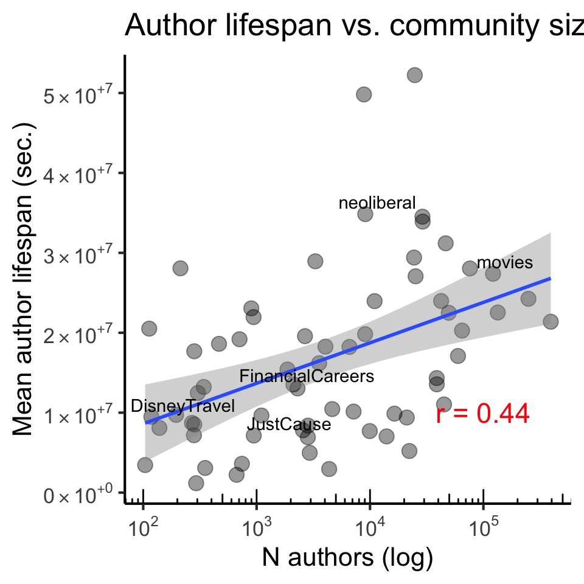

```r
scientific_10 <- function(x) {
  parse(text=gsub("e", "%*%10^", scales::scientific_format()(x)))
}

label_data2 <- author_time %>%
  filter(subreddit %in% c("DisneyTravel", "movies", "neoliberal", "JustCause", "FinancialCareers"))

longevity_corr <- cor.test(log(author_time$author_n), author_time$author_longevity_mean) %>%
  pluck("estimate") %>%
  pluck("cor") %>%
  round(2)


ggplot(author_time, aes(x = author_n, y = author_longevity_mean)) +
  geom_point(size = 4, alpha = .4) +
  geom_smooth(method = "lm")+
  ggtitle("Author lifespan vs. community size") +
  geom_text_repel(data = label_data2, aes(label = subreddit)) +
  scale_y_continuous(name = "Mean author lifespan (sec.)", label = scientific_10) +
   annotate("text", label = paste0("r = ", longevity_corr ),
           x = 100000, y = 10000000, color= "red", size = 6) +
  scale_x_log10(name = "N authors (log)",
                labels = scales::trans_format("log10", scales::math_format(10^.x)))+
  annotation_logticks(sides = "b") +
  theme_classic(base_size = 16)
```

## Churn

```r
CHURN_PATH <- here("exploratory_analyses/03_systematic_sample/data/churn_overtime.csv")

churn <- read_csv(CHURN_PATH, col_names = c("subreddit", "created_bin", "in_churn",
                                            "inout_sum", "comment_length_type")) %>%
  filter(comment_length_type == "all") %>%
  left_join(author_counts) %>%
  mutate(subreddit = fct_reorder(subreddit, author_n))  %>%
  filter(author_n > 100)

in_churn <- churn %>%
  group_by(subreddit) %>%
  summarize(mean_churn = mean(in_churn))
```

### Churn over time

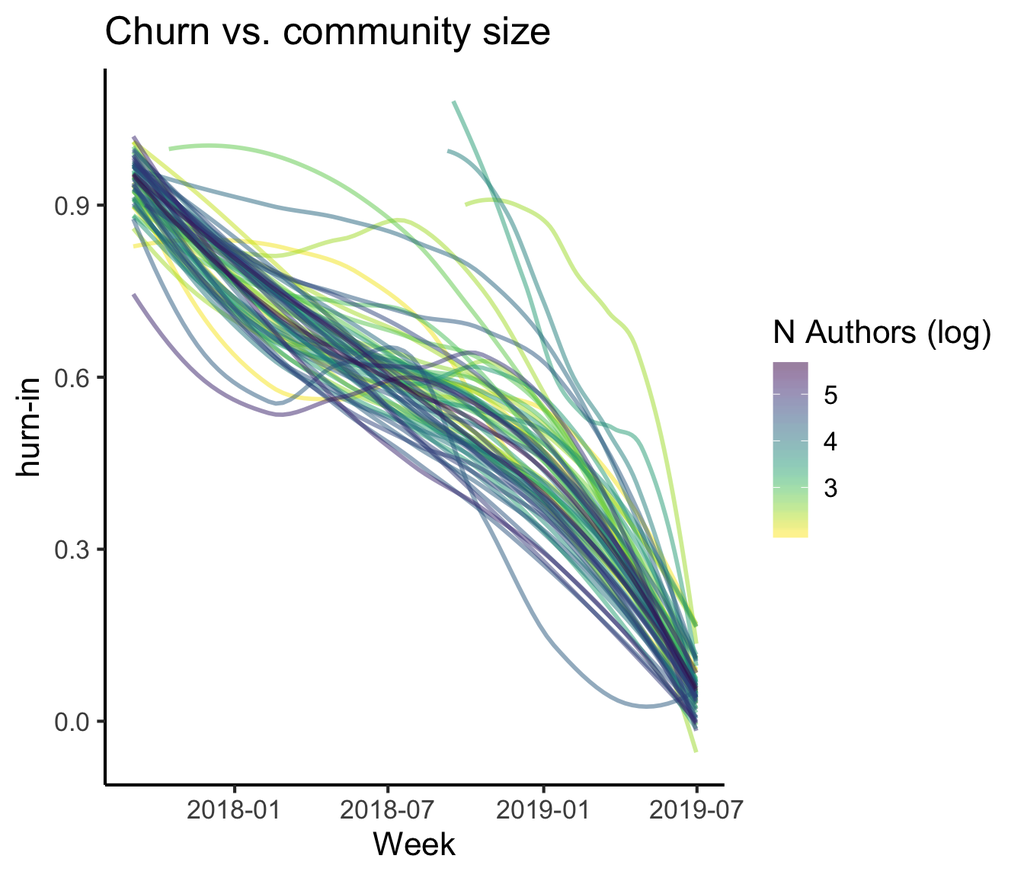

```r
churn %>%
  ggplot(aes(x = created_bin, y = in_churn, color = log10(author_n),
              group = subreddit)) +
  scale_color_viridis(alpha = .5, direction = -1) +
  geom_smooth(se = F) +
  ggtitle("Churn vs. community size") +
  xlab("Week") +
  ylab("hurn-in") +
  labs(color = "N Authors (log)") +
  theme_classic(base_size = 16)
```

### Mean churn

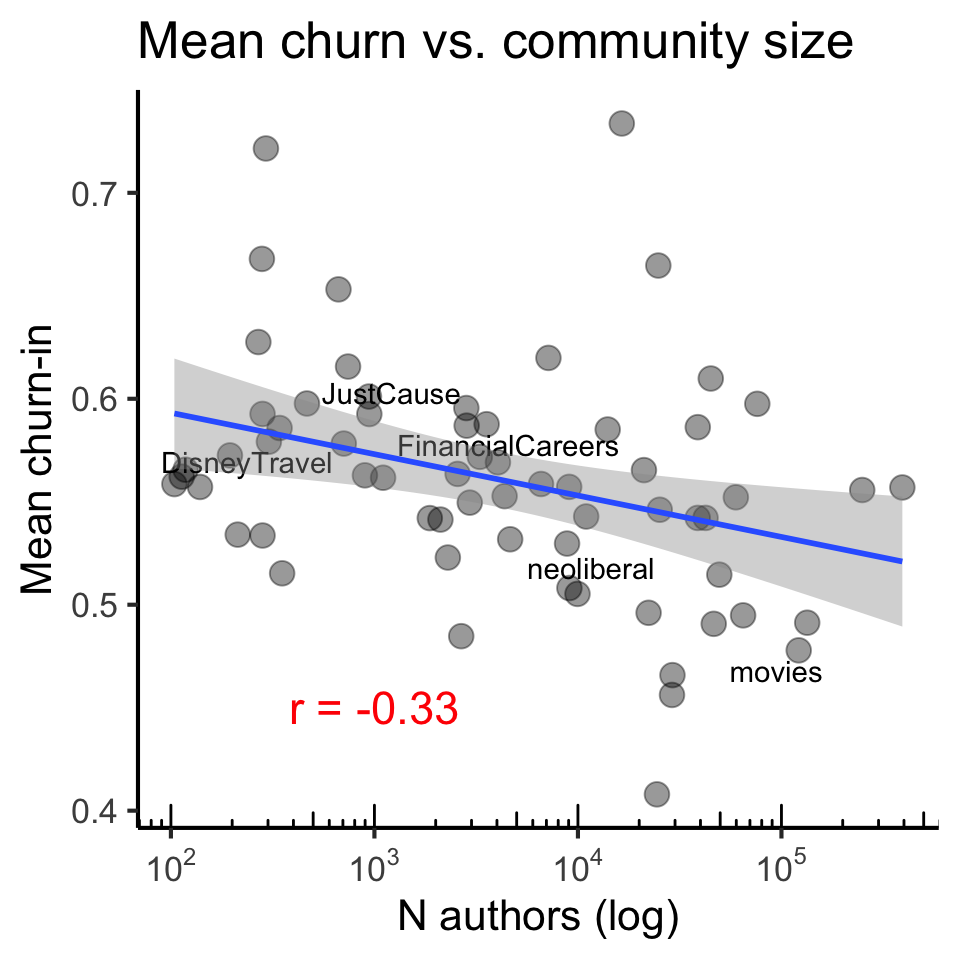

```r
churn_with_author <- in_churn %>%
  left_join(author_counts)

label_data3 <- churn_with_author  %>%
  filter(subreddit %in% c("DisneyTravel", "movies", "neoliberal", "JustCause", "FinancialCareers"))


churn_corr <- cor.test(log(churn_with_author$author_n), churn_with_author$mean_churn) %>%
  pluck("estimate") %>%
  pluck("cor") %>%
  round(2)

ggplot(churn_with_author, aes(x = author_n, y = mean_churn)) +
  geom_point(size = 4, alpha = .4) +
  geom_text_repel(data = label_data3, aes(label = subreddit)) +
  ggtitle("Mean churn vs. community size") +
  ylab("Churn-in") +
  annotate("text", label = paste0("r = ", churn_corr ),
           x = 1000, y = .45, color= "red", size = 6) +
  geom_smooth(method = "lm") +
  ylab("Mean churn-in") +
  scale_x_log10(name = "N authors (log)",
                labels = scales::trans_format("log10", scales::math_format(10^.x)))+
  annotation_logticks(sides = "b") +
  theme_classic(base_size = 16)
```

### Author inequality

Long comments only

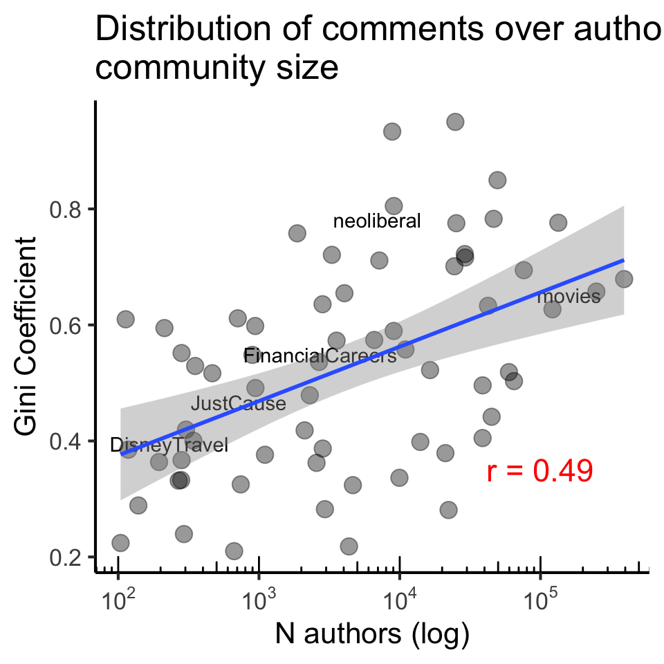

```r
AUTHOR_INEQ_LONG <- here("exploratory_analyses/03_systematic_sample/data/subreddit_author_inequality_long.csv")

author_ineq_long <- read_csv(AUTHOR_INEQ_LONG, col_names = c("subreddit", "comment_author_H",
                                                             "comment_gini_coeff",
                                     "comment_normalized_author_H")) %>%
  left_join(author_counts) %>%
  mutate(subreddit = fct_reorder(subreddit, author_n)) %>%
  filter(author_n > 100)


label_data4 <- author_ineq_long  %>%
  filter(subreddit %in% c("DisneyTravel", "movies", "neoliberal", "JustCause", "FinancialCareers"))


gini_corr <- cor.test(log(author_ineq_long$author_n), author_ineq_long$comment_gini_coeff) %>%
  pluck("estimate") %>%
  pluck("cor") %>%
  round(2)

ggplot(author_ineq_long, aes(x = author_n, y = comment_gini_coeff)) +
  geom_point(size = 4, alpha = .4) +
  geom_text_repel(data = label_data4, aes(label = subreddit)) +
  ggtitle("Distribution of comments over authors vs. \ncommunity size") +
  geom_smooth(method = "lm")+
  ylab("Gini Coefficient") +
    annotate("text", label = paste0("r = ", gini_corr ),
           x = 100000, y = .35, color= "red", size = 6) +
  scale_x_log10(name = "N authors (log)",
                labels = scales::trans_format("log10", scales::math_format(10^.x)))+
  theme_classic() +
  annotation_logticks(sides = "b") +
  theme_classic(base_size = 16)
```